[figure not shown]

[figure not shown]

# Evaluating classifier performance on pathogens

Patrick Schratz, Friedrich-Schiller-University Jena

# 1 Introduction

This document shows the predictive performances for the possible infection risk of trees in the Basque Country by the following pathogens:

- *Armillaria mellea*
- *Diplodia sapinea*
- *Fusarium circinatum*
- *Heterobasidion annosum*

The following algorithms were benchmarked:

- Boosted Regression Trees (BRT)
- Generalized Additive Model (GAM)
- Generalized Linear Model (GLM)
- k-Nearest Neighbor (KNN)
- Random Forests (RF)
- Support Vector Machine (SVM)
- Extreme Gradient Boosting (XGBOOST)

The following “algorithm-pathogen-resampling” settings did not return a performance result during performance evaluation. Due to the missing performance result for these combinations no prediction maps were created.

| Pathogen | Algorithm | Resampling |
| --- | --- | --- |
| Armillaria | XGBOOST | spatial/spatial |
| Armillaria | GAM | spatial/spatial |

Due to two missing results for the pathogen *Armillaria mellea*, this pathogen could not be included in the plots comparing all pathogens against each other.

# 2 Resampling Strategies

The abbreviations of the tabbed resampling strategies follow the scheme:

`<outer resampling> / <inner resampling>`

For example, setting “Spatial-Spatial” means that in both levels a “spatial cross-validation” (Brenning (2012)) has been applied.

The inner resampling refers to the hyperparameter tuning level of the nested cross-validation that was applied.

# 3 Results structure

The structure of the following results presentation is as follows:

- Table view of all performances for each resampling setting
- Boxplot comparison for each pathogen and algorithm
- Aggregated performances for each pathogen and algorithm

# 4 Resampling strategies

## 4.1 Spatial-Spatial

```
##           task.id            learner.id brier.test.mean
## 1        diplodia classif.xgboost.tuned       0.2178637
## 2        diplodia     classif.svm.tuned       0.2000721
## 3        diplodia     classif.gam.tuned       0.1899124
## 4        diplodia    classif.kknn.tuned       0.1877918
## 5        diplodia  classif.ranger.tuned       0.1594762
## 6        diplodia     classif.gbm.tuned       0.1590360
## 7        fusarium classif.xgboost.tuned       0.1922855
## 8        fusarium    classif.kknn.tuned       0.1515723
## 9        fusarium     classif.svm.tuned       0.1439149
## 10       fusarium     classif.gam.tuned       0.1283013
## 11       fusarium     classif.gbm.tuned       0.1277329
## 12       fusarium  classif.ranger.tuned       0.1225918
## 13 heterobasidion classif.xgboost.tuned       0.2129888
## 14 heterobasidion     classif.gam.tuned       0.1958724
```

[output cut: 23 more lines]

### 4.1.1 Boxplot comparison

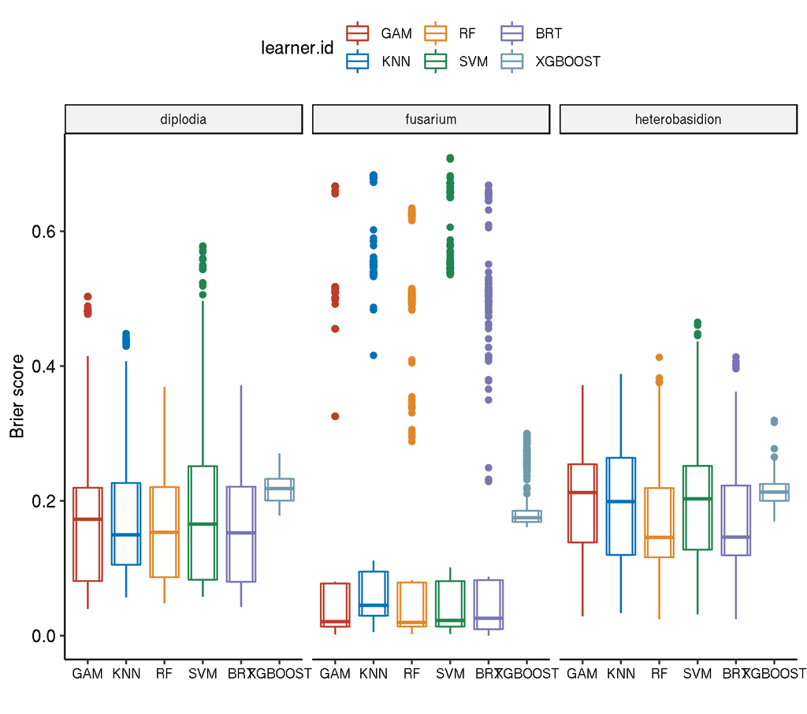

### 4.1.2 Aggregated performances

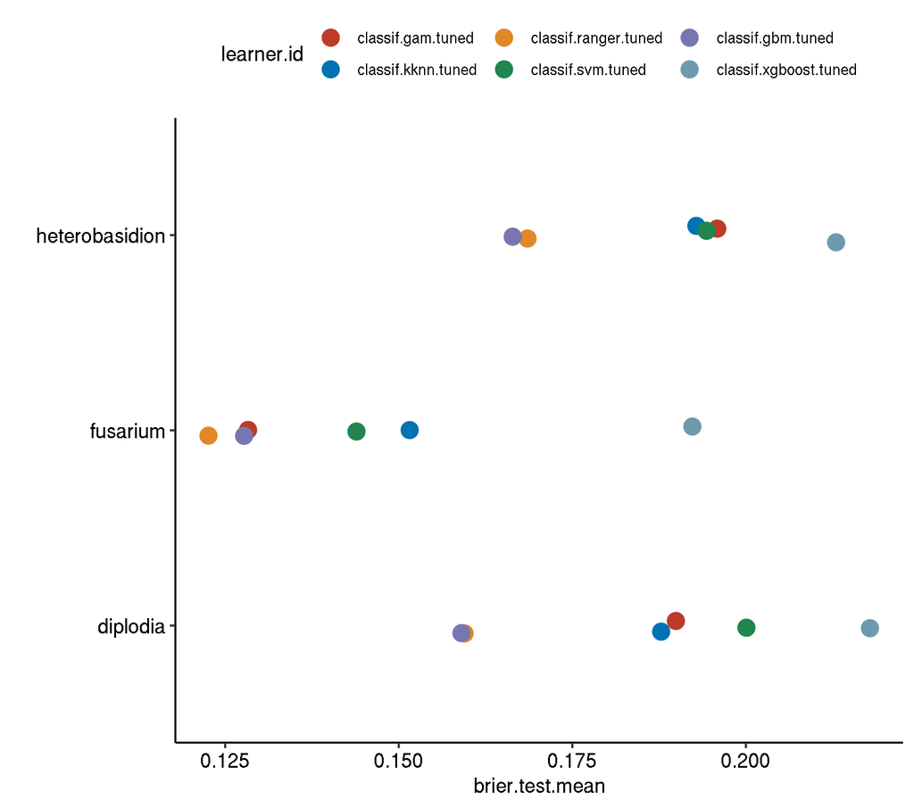

## 4.2 Spatial-Non-Spatial

```
##           task.id            learner.id brier.test.mean
## 1      armillaria     classif.gam.tuned       0.3013001
## 2      armillaria    classif.kknn.tuned       0.2939335
## 3      armillaria     classif.gbm.tuned       0.2935869
## 4      armillaria classif.xgboost.tuned       0.2487059
## 5      armillaria     classif.svm.tuned       0.2412515
## 6      armillaria  classif.ranger.tuned       0.2396800
## 7        diplodia classif.xgboost.tuned       0.2144304
## 8        diplodia     classif.svm.tuned       0.2125015
## 9        diplodia     classif.gam.tuned       0.1922458
## 10       diplodia    classif.kknn.tuned       0.1882630
## 11       diplodia     classif.gbm.tuned       0.1637896
## 12       diplodia  classif.ranger.tuned       0.1528584
## 13       fusarium classif.xgboost.tuned       0.1903816
## 14       fusarium    classif.kknn.tuned       0.1517528
```

[output cut: 35 more lines]

### 4.2.1 Boxplot comparison

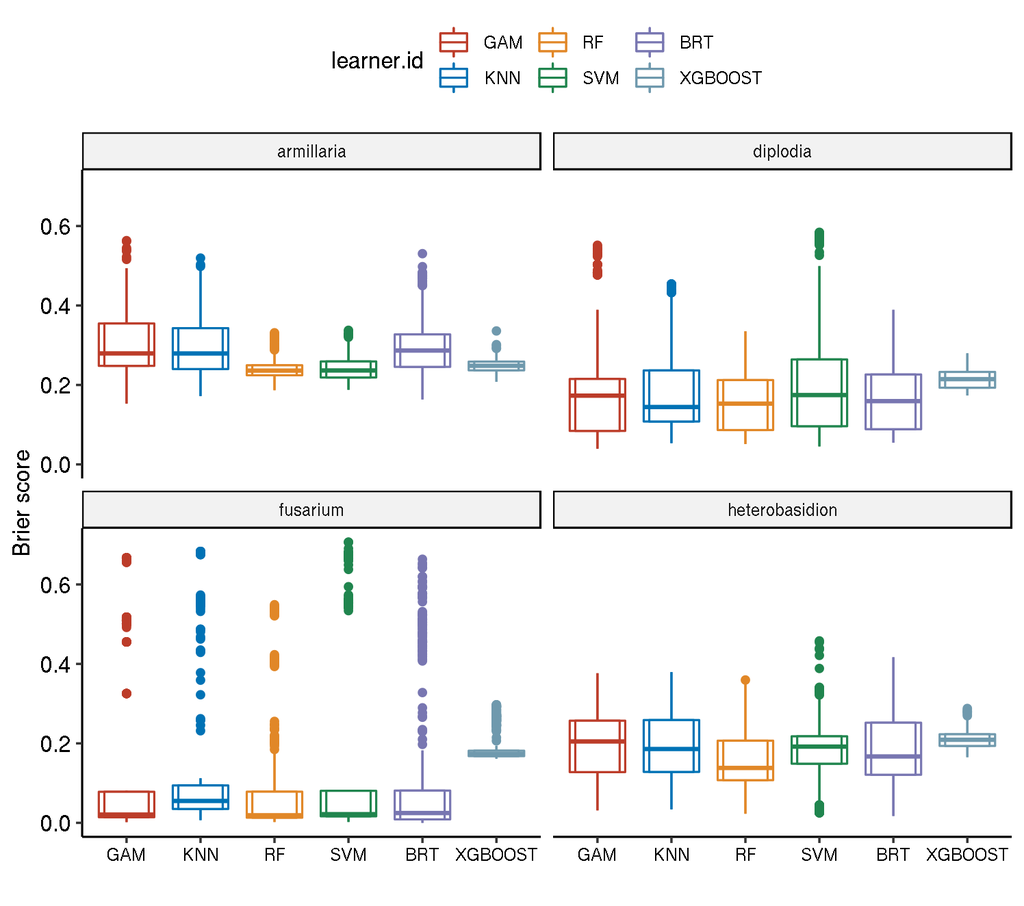

### 4.2.2 Aggregated performances

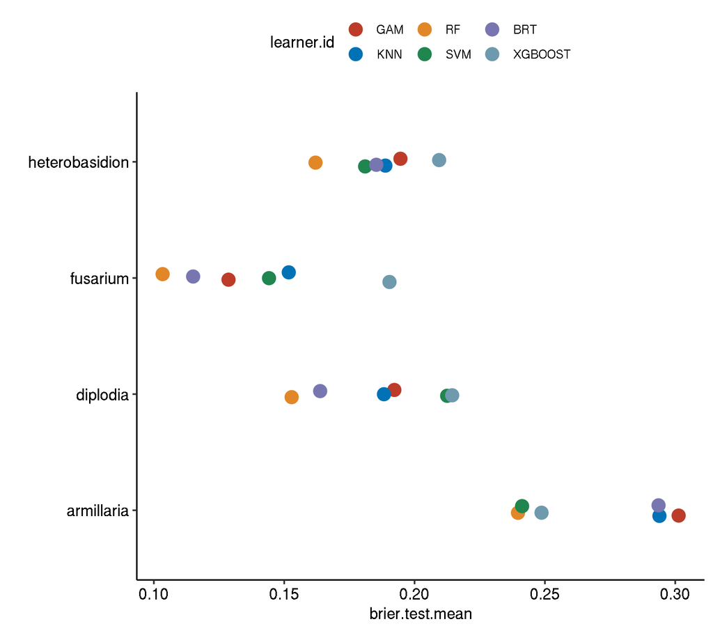

## 4.3 Non-Spatial-Non-Spatial

```
##           task.id            learner.id brier.test.mean
## 1      armillaria     classif.gam.tuned      0.22700637
## 2      armillaria classif.xgboost.tuned      0.20195496
## 3      armillaria    classif.kknn.tuned      0.13283583
## 4      armillaria     classif.svm.tuned      0.13054167
## 5      armillaria     classif.gbm.tuned      0.12190209
## 6      armillaria  classif.ranger.tuned      0.10428849
## 7        diplodia classif.xgboost.tuned      0.19924264
## 8        diplodia     classif.gam.tuned      0.13952038
## 9        diplodia     classif.svm.tuned      0.12296446
## 10       diplodia    classif.kknn.tuned      0.12013106
## 11       diplodia     classif.gbm.tuned      0.11186382
## 12       diplodia  classif.ranger.tuned      0.09952600
## 13       fusarium classif.xgboost.tuned      0.17346649
## 14       fusarium     classif.gam.tuned      0.06053425
```

[output cut: 35 more lines]

### 4.3.1 Boxplot comparison

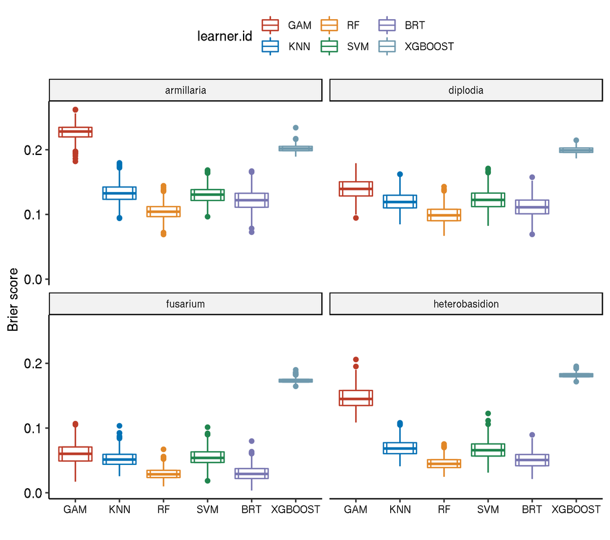

### 4.3.2 Aggregated performances

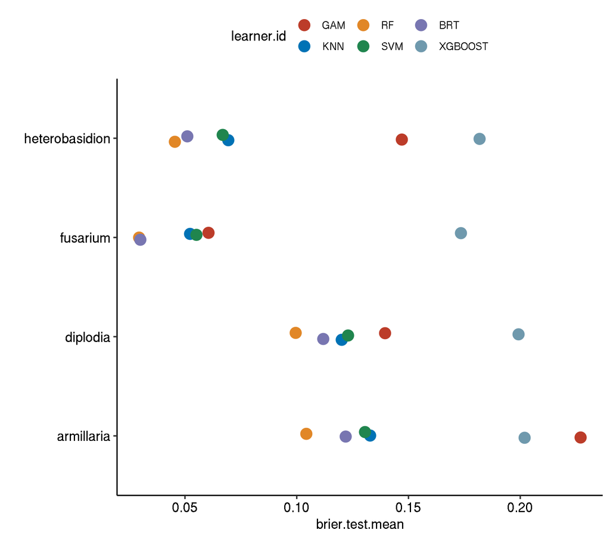

## 4.4 Non-Spatial-No Tuning

```
##           task.id       learner.id brier.test.mean timetrain.test.mean
## 1      armillaria classif.binomial      0.23430477            0.020556
## 2      armillaria  classif.xgboost      0.19308152            0.492520
## 3      armillaria      classif.gbm      0.17435081            0.046698
## 4      armillaria      classif.gam      0.16339620            0.344802
## 5      armillaria     classif.kknn      0.14319871            0.000606
## 6      armillaria      classif.svm      0.14008004            0.199052
## 7      armillaria   classif.ranger      0.10934871            0.287948
## 8        diplodia  classif.xgboost      0.18104208            0.579908
## 9        diplodia      classif.svm      0.16032300            0.246286
## 10       diplodia      classif.gam      0.14672641            0.395882
## 11       diplodia     classif.kknn      0.11956687            0.000578
## 12       diplodia classif.binomial      0.11861260            0.019850
## 13       diplodia      classif.gbm      0.11375122            0.050644
## 14       diplodia   classif.ranger      0.10170460            0.261038
## 15       fusarium  classif.xgboost      0.14483346            0.171418
## 16       fusarium      classif.svm      0.07603583            0.262310
## 17       fusarium      classif.gam      0.07261828            0.520834
## 18       fusarium     classif.kknn      0.05268736            0.001084
## 19       fusarium classif.binomial      0.04841708            0.032960
## 20       fusarium      classif.gbm      0.03622046            0.073710
## 21       fusarium   classif.ranger      0.03103918            0.199382
## 22 heterobasidion classif.binomial      0.16290012            0.026578
## 23 heterobasidion  classif.xgboost      0.16076201            0.227860
## 24 heterobasidion      classif.gbm      0.09434126            0.048094
## 25 heterobasidion      classif.gam      0.08696898            0.381824
## 26 heterobasidion     classif.kknn      0.07479138            0.000672
## 27 heterobasidion      classif.svm      0.06915348            0.189382
## 28 heterobasidion   classif.ranger      0.04976475            0.252730
```

### 4.4.1 Boxplot comparison

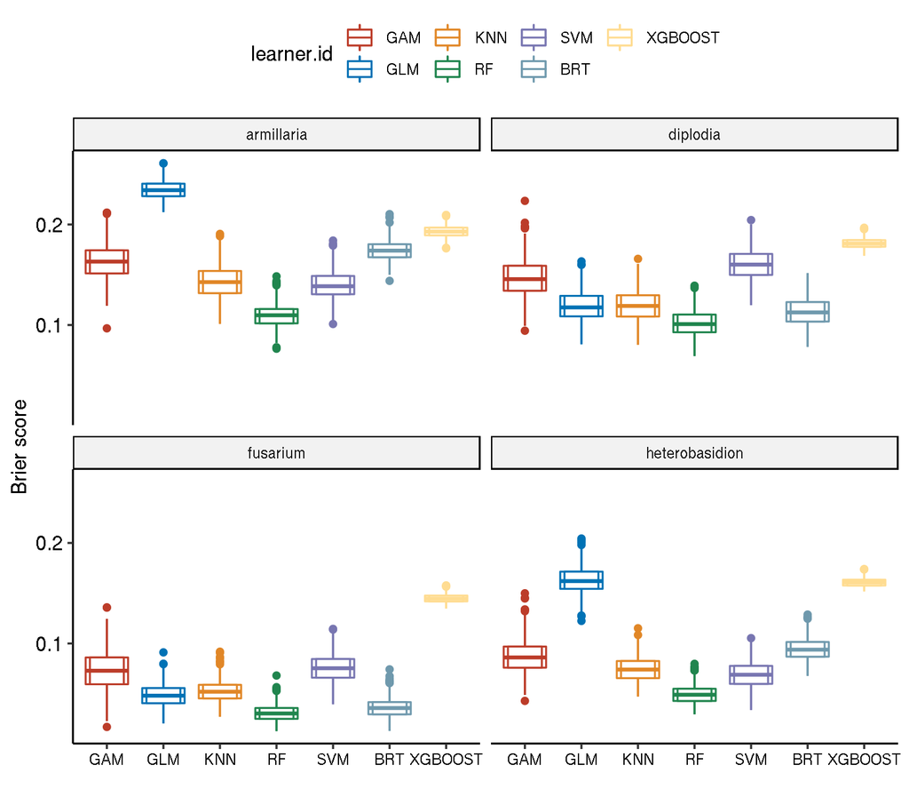

### 4.4.2 Aggregated performances

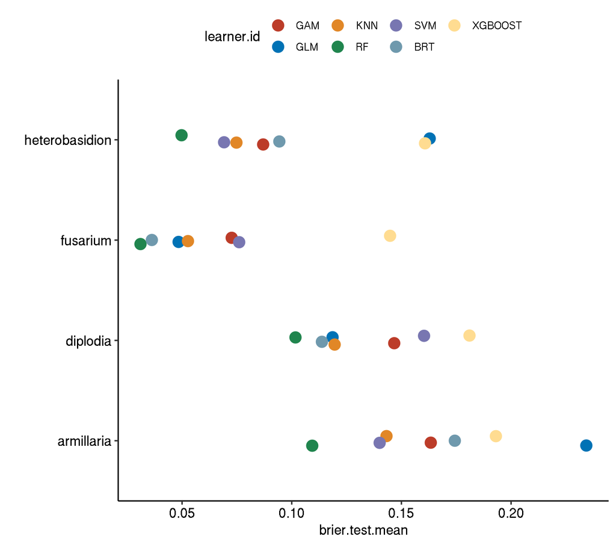

## 4.5 Spatial-No Tuning

```
##           task.id       learner.id brier.test.mean timetrain.test.mean
## 1      armillaria      classif.gam      0.34203122            0.291280
## 2      armillaria     classif.kknn      0.28773607            0.000554
## 3      armillaria classif.binomial      0.28400164            0.020448
## 4      armillaria      classif.gbm      0.27648700            0.045978
## 5      armillaria  classif.xgboost      0.25095005            0.504856
## 6      armillaria      classif.svm      0.25076442            0.192162
## 7      armillaria   classif.ranger      0.23791242            0.266582
## 8        diplodia      classif.gam      0.25052534            0.366116
## 9        diplodia      classif.svm      0.20094838            0.244696
## 10       diplodia  classif.xgboost      0.19986164            0.399858
## 11       diplodia classif.binomial      0.17030072            0.019524
## 12       diplodia     classif.kknn      0.16892370            0.000540
## 13       diplodia      classif.gbm      0.15981173            0.051166
## 14       diplodia   classif.ranger      0.14990091            0.259162
## 15       fusarium  classif.xgboost      0.17056495            0.171358
## 16       fusarium      classif.svm      0.15712093            0.253972
## 17       fusarium      classif.gam      0.13216430            0.516134
## 18       fusarium     classif.kknn      0.13069975            0.000852
## 19       fusarium      classif.gbm      0.10680714            0.074078
## 20       fusarium   classif.ranger      0.10410518            0.191088
## 21       fusarium classif.binomial      0.09171266            0.042224
## 22 heterobasidion      classif.gam      0.25236362            0.397666
## 23 heterobasidion classif.binomial      0.19785015            0.026464
## 24 heterobasidion  classif.xgboost      0.19305571            0.152206
## 25 heterobasidion      classif.gbm      0.18311438            0.050108
## 26 heterobasidion      classif.svm      0.18252532            0.187578
## 27 heterobasidion     classif.kknn      0.17918672            0.000610
## 28 heterobasidion   classif.ranger      0.16098088            0.240746
```

### 4.5.1 Boxplot comparison

[output not shown]

[figure not shown]

### 4.5.2 Aggregated performances

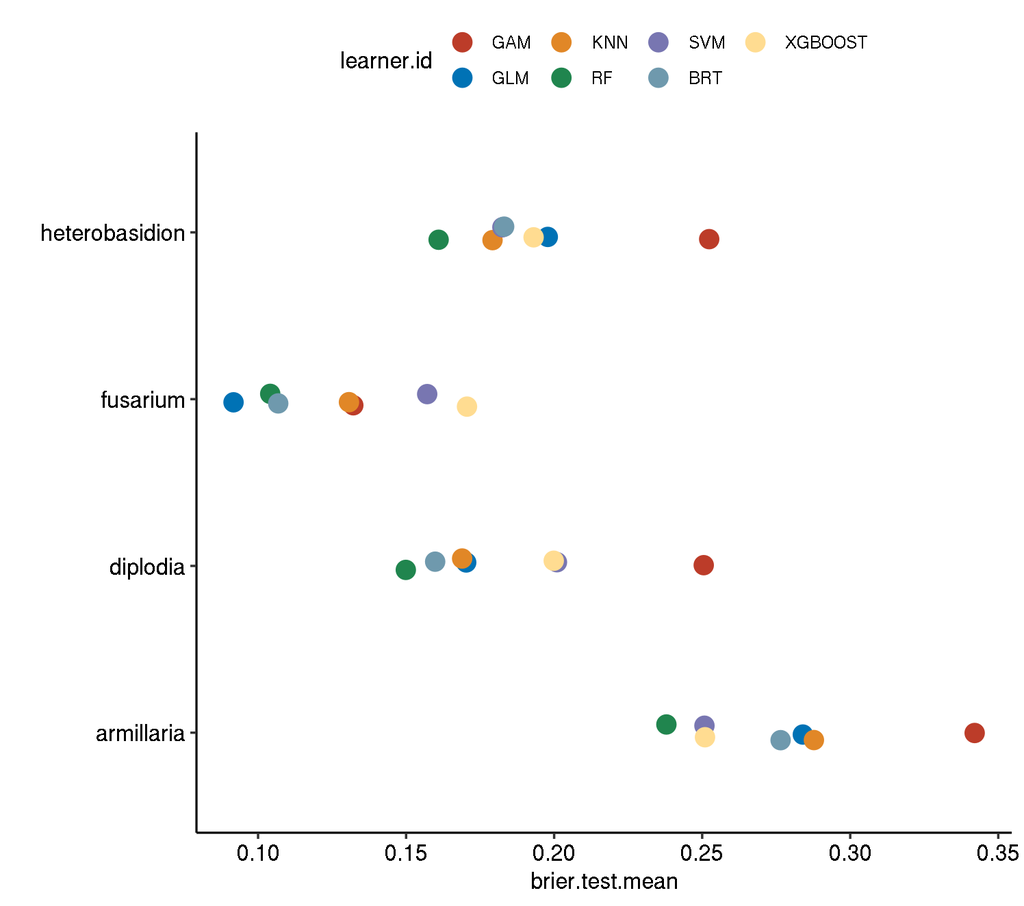

# References

Brenning, A. 2012. “Spatial Cross-Validation and Bootstrap for the Assessment of Prediction Rules in Remote Sensing: The R Package Sperrorest.” In *2012 Ieee International Geoscience and Remote Sensing Symposium*, 5372–5. https://doi.org/10.1109/IGARSS.2012.6352393.